# Gender Decomposition — Female Labour Force Participation and Structural Change

## Overview

This notebook examines gender differences in employment structure across Indian districts using the PLFS panel 2017-18 to 2023-24. The analysis focuses on three questions: how do female and male non-agricultural employment shares differ nationally and across districts; is the gender gap in non-agricultural employment narrowing over the panel period; and which districts show the greatest female non-agricultural participation.

Given the NCO coding quality constraints documented in Notebook 3, the three-way skill classification is not used here. All analysis uses the agri/non-agri binary classification, which is internally consistent across rounds. The 2017-18 urban sex data is excluded throughout — as documented in `01_clean.Rmd`, nearly 50% of urban 2017-18 observations have missing sex values due to the rotating panel visit structure.

```r
library(tidyverse)
library(patchwork)
library(scales)
```

## Load Data and Apply Filters

We load the agri panel and apply three filters: balanced panel restriction, minimum cell size of 25, and exclusion of the 2017-18 urban sex-disaggregated data. We then separate the overall (sex = “all”) and sex-disaggregated observations for distinct uses throughout the notebook.

```r
agri <- readRDS("~/Desktop/UZH/Pre-Doc/Prep/BRICS-Trade-Labour-Portfolio/03_labour_polarisation_india/data/plfs_agri_panel.rds")

MIN_N <- 25

# Overall panel — used for national totals and district counts
agri_overall <- agri |>
  filter(balanced_panel == TRUE,
         emp_n >= MIN_N,
         sex == "all",
         agri_nonagri == "non_agricultural")

# Sex-disaggregated panel — exclude 2017-18 urban (unreliable sex data)
agri_sex <- agri |>
  filter(balanced_panel == TRUE,
         emp_n >= MIN_N,
         sex %in% c("male", "female"),
         agri_nonagri == "non_agricultural",
         !(round == "2017-18" & file_sector == "urban"))

cat("Overall panel rows:", nrow(agri_overall), "\n")
```

```
## Overall panel rows: 5813
```

```r
cat("Sex-disaggregated panel rows:", nrow(agri_sex), "\n\n")
```

```
## Sex-disaggregated panel rows: 6073
```

```r
# District counts by round, sector, sex
cat("=== Districts retained by round, sector, and sex ===\n")
```

```
## === Districts retained by round, sector, and sex ===
```

```r
agri_sex |>
  count(year, file_sector, sex) |>
  pivot_wider(names_from = sex, values_from = n) |>
  arrange(file_sector, year) |>
  print(n = 20)
```

```
## # A tibble: 13 × 4
##     year file_sector female  male
##    <int> <chr>        <int> <int>
##  1  2018 rural           50   262
##  2  2019 rural          100   387
##  3  2020 rural           98   372
##  4  2021 rural          100   389
##  5  2022 rural          114   396
##  6  2023 rural          126   387
##  7  2024 rural          147   384
##  8  2019 urban           62   375
##  9  2020 urban           65   383
## 10  2021 urban           65   386
## 11  2022 urban           68   394
## 12  2023 urban           74   414
## 13  2024 urban           80   395
```

This has two implications. First, district-level gender comparisons in this notebook are based on a selected sample of districts where female employment is relatively higher — systematically excluding districts with the lowest female participation, which are likely the most important ones for understanding gender gaps. Second, the sparse female coverage is itself an empirical finding: female employment is thin enough in Indian districts that a nationally representative survey with ~100,000 households cannot reliably estimate district-level female employment structure in the majority of districts.

The analysis therefore proceeds at two levels: national weighted aggregates (covering all districts through the weighting, not just those passing the cell size filter) and district-level comparisons restricted to the subset of districts with adequate female samples.

## National Gender Trends

We compute national non-agricultural employment shares separately for male and female workers, weighted by district employment totals, using the full balanced panel without the cell size filter to avoid selection bias in the national aggregate.

```r
# National non-agri shares by sex and round
# Use full balanced panel (no cell size filter) for national aggregates
national_gender <- agri |>
  filter(balanced_panel == TRUE,
         sex %in% c("male", "female"),
         agri_nonagri == "non_agricultural",
         !(round == "2017-18" & file_sector == "urban")) |>
  group_by(year, file_sector, sex) |>
  summarise(
    emp_wtd_total = sum(emp_wtd),
    .groups = "drop"
  ) |>
  group_by(year, file_sector) |>
  mutate(
    total_emp     = sum(emp_wtd_total),
    national_share = emp_wtd_total / total_emp
  ) |>
  ungroup()

# Print table
cat("=== National non-agricultural share by sex, sector, and round ===\n")
```

```
## === National non-agricultural share by sex, sector, and round ===
```

```r
national_gender |>
  select(year, file_sector, sex, national_share) |>
  mutate(national_share = round(national_share * 100, 1)) |>
  pivot_wider(names_from = sex, values_from = national_share) |>
  mutate(gender_gap = male - female) |>
  arrange(file_sector, year) |>
  print(n = 13)
```

```
## # A tibble: 13 × 5
##     year file_sector female  male gender_gap
##    <int> <chr>        <dbl> <dbl>      <dbl>
##  1  2018 rural         16.2  83.8       67.6
##  2  2019 rural         16.5  83.5       67
##  3  2020 rural         18.5  81.5       63
##  4  2021 rural         17.9  82.1       64.2
##  5  2022 rural         17.1  82.9       65.8
##  6  2023 rural         19.6  80.4       60.8
##  7  2024 rural         21.3  78.7       57.4
##  8  2019 urban         17    83         66
##  9  2020 urban         18.7  81.3       62.6
## 10  2021 urban         18.3  81.7       63.4
## 11  2022 urban         18.3  81.7       63.4
## 12  2023 urban         19.3  80.7       61.4
## 13  2024 urban         19.9  80.1       60.2
```

The table shows the gender composition of the non-agricultural workforce — what fraction of non-agricultural employed persons are female versus male. Nationally, women account for only 16-21% of non-agricultural employment, with men accounting for the remainder. The gender gap (male share minus female share) is narrowing over time — from 67.6 to 57.4 percentage points in rural areas and from 66.0 to 60.2 points in urban areas — indicating a gradual shift in the gender composition of non-agricultural work toward greater female representation.

However, this measure conflates two distinct phenomena: the occupational structure of female employment and the overall level of female labour force participation. A more informative measure for this analysis is the non-agricultural employment share within each sex separately — of all employed women, what fraction work in non-agricultural occupations, and how does this compare to men? We compute this next.

## Non-Agricultural Employment Share Within Each Sex

```r
# Compute non-agri share WITHIN each sex
# Requires both agri and non-agri rows to get denominator
within_sex <- agri |>
  filter(balanced_panel == TRUE,
         sex %in% c("male", "female"),
         !(round == "2017-18" & file_sector == "urban")) |>
  group_by(year, file_sector, sex, agri_nonagri) |>
  summarise(emp_wtd_total = sum(emp_wtd), .groups = "drop") |>
  group_by(year, file_sector, sex) |>
  mutate(
    total_sex_emp  = sum(emp_wtd_total),
    within_share   = emp_wtd_total / total_sex_emp
  ) |>
  ungroup() |>
  filter(agri_nonagri == "non_agricultural") |>
  select(year, file_sector, sex, within_share)

cat("=== Non-agricultural share within each sex ===\n")
```

```
## === Non-agricultural share within each sex ===
```

```r
within_sex |>
  mutate(within_share = round(within_share * 100, 1)) |>
  pivot_wider(names_from = sex, values_from = within_share) |>
  mutate(gender_gap = male - female) |>
  arrange(file_sector, year) |>
  print(n = 13)
```

```
## # A tibble: 13 × 5
##     year file_sector female  male gender_gap
##    <int> <chr>        <dbl> <dbl>      <dbl>
##  1  2018 rural         81.4  86.2       4.8
##  2  2019 rural         80.9  86.4       5.5
##  3  2020 rural         81.6  86         4.40
##  4  2021 rural         80.5  85.3       4.8
##  5  2022 rural         80    86.9       6.90
##  6  2023 rural         77.7  87.3       9.6
##  7  2024 rural         75.9  87.7      11.8
##  8  2019 urban         30.7  41.6      10.9
##  9  2020 urban         27.4  41.4      14
## 10  2021 urban         24.7  41.6      16.9
## 11  2022 urban         25.2  42.2      17
## 12  2023 urban         24.5  44.2      19.7
## 13  2024 urban         23.9  43.2      19.3
```

The within-sex analysis reveals a striking and consistent pattern. Male non-agricultural employment share is broadly stable across the panel — rural males hover between 85-88%, urban males between 41-44% — with no clear directional trend. Female non-agricultural employment share is declining in both sectors, and the gender gap is widening.

In rural areas, female non-agricultural share falls from 81.4% in 2018 to 75.9% in 2024 — a 5.5 percentage point decline over six years — while male share rises slightly from 86.2% to 87.7%. The rural gender gap widens from 4.8 points to 11.8 points.

In urban areas the pattern is more pronounced. Female non-agricultural share falls from 30.7% in 2019 to 23.9% in 2024 — a 6.8 point decline — while male share is broadly stable at 41-44%. The urban gender gap widens from 10.9 to 19.3 points.

Three interpretations of this widening gap must be held simultaneously. First, it may reflect a genuine economic phenomenon: employed women in India are increasingly concentrated in agricultural-coded occupations relative to men, consistent with the broader literature documenting declining female LFPR and the feminisation of agricultural work in India as men exit to non-farm employment. Second, the NCO coding quality issues documented in Notebook 3 — particularly the large urban NCO 611 (market gardener) category — may affect women more than men: women working in informal urban food markets or as street vegetable vendors may be disproportionately coded as agricultural relative to men doing structurally similar informal work. Third, the rural widening from 2022-23 onwards coincides with the NCO coding revision, which may have reclassified women’s occupations differently from men’s.

The widening gender gap is reported as a finding with explicit acknowledgement that both genuine economic dynamics and coding artefacts are plausible contributors. The direction of the finding — women increasingly classified as agricultural relative to men — is consistent with Indian labour market evidence but cannot be definitively attributed to economic rather than measurement causes from this data alone.

## Visualising the Gender Gap

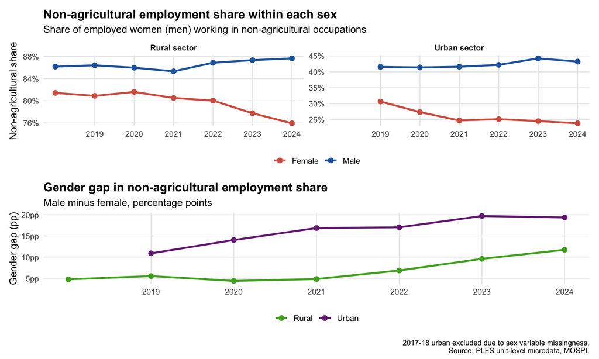

```r
# Line plot: within-sex non-agri shares over time
sector_labels <- c(rural = "Rural sector", urban = "Urban sector")

p_lines <- within_sex |>
  mutate(sex = str_to_title(sex)) |>
  ggplot(aes(x = year, y = within_share * 100,
             colour = sex, group = sex)) +
  geom_line(linewidth = 1.1) +
  geom_point(size = 2.5) +
  scale_colour_manual(values = c(Female = "#d6604d", Male = "#2166ac"),
                      name = NULL) +
  scale_x_continuous(breaks = 2019:2024) +
  scale_y_continuous(labels = label_number(suffix = "%")) +
  facet_wrap(~file_sector,
             scales = "free_y",
             labeller = labeller(file_sector = sector_labels)) +
  labs(title    = "Non-agricultural employment share within each sex",
       subtitle = "Share of employed women (men) working in non-agricultural occupations",
       x = NULL, y = "Non-agricultural share") +
  theme_minimal(base_size = 12) +
  theme(legend.position  = "bottom",
        panel.grid.minor = element_blank(),
        plot.title       = element_text(face = "bold"),
        strip.text       = element_text(face = "bold"))

# Gap plot: male minus female
p_gap <- within_sex |>
  pivot_wider(names_from = sex, values_from = within_share) |>
  mutate(gap = (male - female) * 100) |>
  ggplot(aes(x = year, y = gap, colour = file_sector, group = file_sector)) +
  geom_line(linewidth = 1.1) +
  geom_point(size = 2.5) +
  scale_colour_manual(values = c(rural = "#4dac26", urban = "#762a83"),
                      labels = c(rural = "Rural", urban = "Urban"),
                      name = NULL) +
  scale_x_continuous(breaks = 2019:2024) +
  scale_y_continuous(labels = label_number(suffix = "pp")) +
  labs(title    = "Gender gap in non-agricultural employment share",
       subtitle = "Male minus female, percentage points",
       x = NULL, y = "Gender gap (pp)") +
  theme_minimal(base_size = 12) +
  theme(legend.position  = "bottom",
        panel.grid.minor = element_blank(),
        plot.title       = element_text(face = "bold"))

(p_lines / p_gap) +
  plot_annotation(
    caption = "2017-18 urban excluded due to sex variable missingness.\nSource: PLFS unit-level microdata, MOSPI."
  )
```

The urban female decline is particularly notable: from 31% non-agricultural in 2019 to 24% in 2024, while urban male is broadly stable at 41-44%. Urban employed women are increasingly classified in agricultural occupations relative to men — a pattern consistent with both the NCO 611 coding issue and the documented decline in Indian female LFPR in urban areas over this period.

## District-Level Female Non-Agricultural Share

We examine the distribution of female non-agricultural employment shares across districts — restricted to the subset with adequate female sample sizes — to identify geographic heterogeneity.

```r
# Distribution of female non-agri share across districts
female_dist <- agri_sex |>
  filter(sex == "female") |>
  mutate(year_label = paste0(year - 1, "-", substr(year, 3, 4)))

cat("=== Female non-agricultural share distribution across districts ===\n")
```

```
## === Female non-agricultural share distribution across districts ===
```

```r
female_dist |>
  group_by(year, file_sector) |>
  summarise(
    n_districts = n(),
    mean   = round(mean(agri_share) * 100, 1),
    sd     = round(sd(agri_share) * 100, 1),
    p25    = round(quantile(agri_share, 0.25) * 100, 1),
    median = round(median(agri_share) * 100, 1),
    p75    = round(quantile(agri_share, 0.75) * 100, 1),
    .groups = "drop"
  ) |>
  arrange(file_sector, year) |>
  print(n = 13)
```

```
## # A tibble: 13 × 8
##     year file_sector n_districts  mean    sd   p25 median   p75
##    <int> <chr>             <int> <dbl> <dbl> <dbl>  <dbl> <dbl>
##  1  2018 rural                50  86.8  10.2  79     86.4  95.3
##  2  2019 rural               100  85    12    79.2   85.8  94.5
##  3  2020 rural                98  85.4  14.6  78.1   89.5  96.9
##  4  2021 rural               100  83.7  13.9  76.3   87.3  94.6
##  5  2022 rural               114  84.1  14    74.7   88.1  94.9
##  6  2023 rural               126  81.2  15.5  71.7   84.6  93.3
##  7  2024 rural               147  78.3  16.1  66.2   82.9  90.3
##  8  2019 urban                62  63.3  23.7  43.5   65.8  86
##  9  2020 urban                65  61.3  22.8  39.8   62.7  78.9
## 10  2021 urban                65  58.2  22.3  41.3   58.1  78.2
## 11  2022 urban                68  56.5  23.1  34.2   55.8  77.7
## 12  2023 urban                74  50.7  23.9  33.5   45.7  69.3
## 13  2024 urban                80  52.2  25    28.9   50.7  73.6
```

```r
# Compare male vs female distribution in districts where both are available
cat("\n=== Mean non-agri share in districts with both sexes available ===\n")
```

```
##
## === Mean non-agri share in districts with both sexes available ===
```

```r
agri_sex |>
  filter(year == 2023) |>
  group_by(file_sector, sex) |>
  summarise(
    n_districts    = n(),
    mean_nonagri   = round(mean(agri_share) * 100, 1),
    median_nonagri = round(median(agri_share) * 100, 1),
    .groups = "drop"
  ) |>
  print()
```

```
## # A tibble: 4 × 5
##   file_sector sex    n_districts mean_nonagri median_nonagri
##   <chr>       <chr>        <int>        <dbl>          <dbl>
## 1 rural       female         126         81.2           84.6
## 2 rural       male           387         85.5           88.7
## 3 urban       female          74         50.7           45.7
## 4 urban       male           414         50.1           47.3
```

The 2023 direct comparison between male and female districts is striking but requires careful interpretation: urban female non-agricultural share (50.7%) appears nearly identical to urban male (50.1%). This is a selection artefact — the 74 female districts are precisely those with high enough female employment to generate reliable estimates, which are disproportionately districts with high female labour force participation and non-agricultural work. The 414 male districts cover the full range including districts where female employment is negligible.

## Summary

The gender gap in non-agricultural employment is widening. Of all employed women, a declining share work in non-agricultural occupations — from 81% to 76% in rural areas and 31% to 24% in urban areas — while male shares are stable or rising. The urban gender gap has widened from 11 to 19 percentage points over six years.

The direction of the female trend is consistent with existing evidence but cannot be cleanly attributed to economic versus measurement causes. The decline in female non-agricultural share is consistent with the documented feminisation of agriculture in India — men exiting agricultural work faster than women — but the NCO coding quality issues documented in Notebook 3 mean coding bias cannot be ruled out as a partial contributor.

**Proceed to `05_urban_rural.Rmd`.**